# spacetimeadultanalysis

A histogram of exponentiated word distances from “long”.

Exponentiating the distances spaces out further distances. This helps deal with the fact that in any space, there are more things further from you than closer to you: a unit increase in radius corresponds to a unit squared increase in area covered. The transformation helps normalize the distribution of words over distance. Throughout, we will be using exponentiated distances.

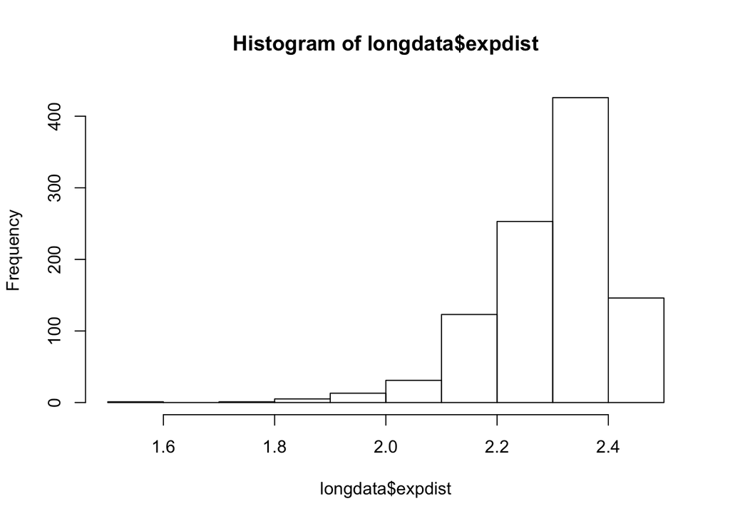

A histogram of exponentiated word distances from “short”.

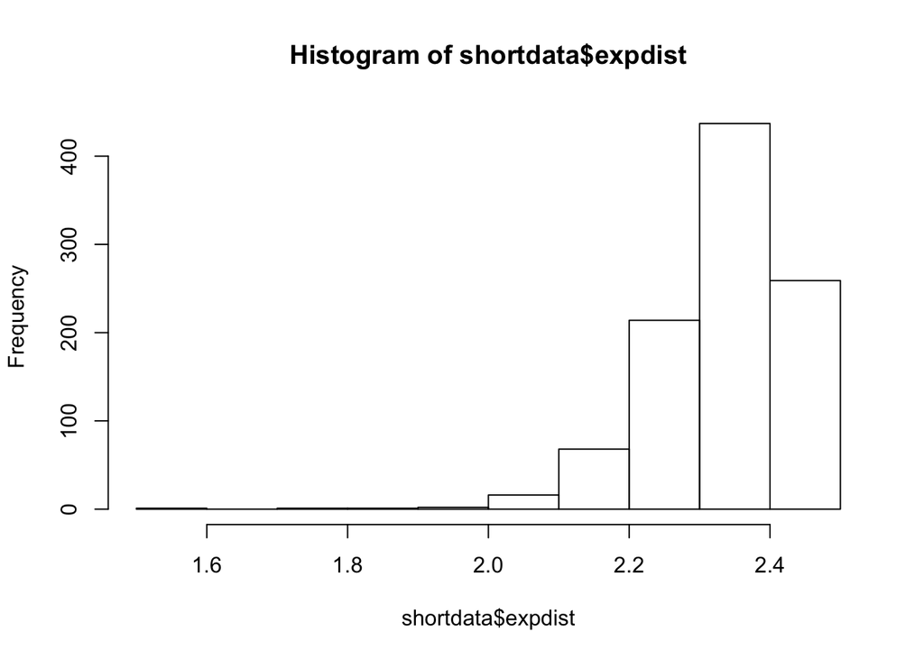

Mean distances of space, time, both and other words from “long”. Error bars here and throughout are 95% bootstrapped confidence intervals.

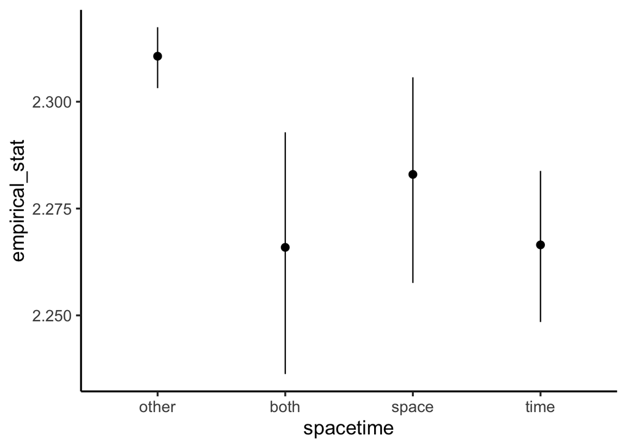

Mean distances of space, time, both and other words from “short”.

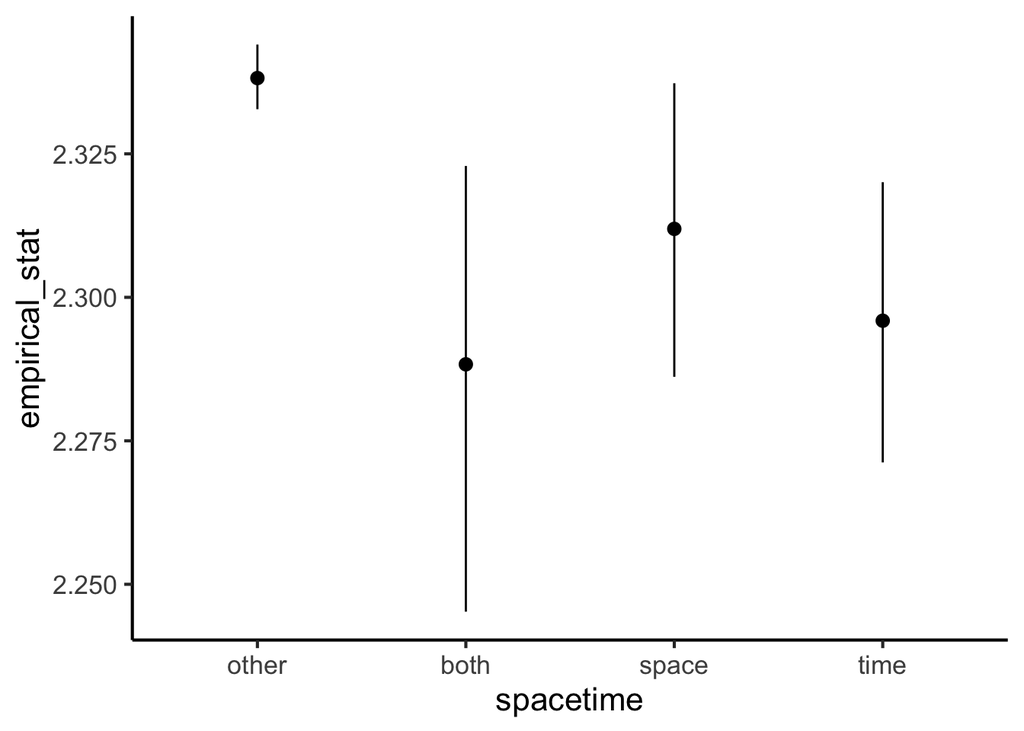

A plot of mean distances of space, time, both and other words from “long” within the closest 20, 100, and 999 neighbors.

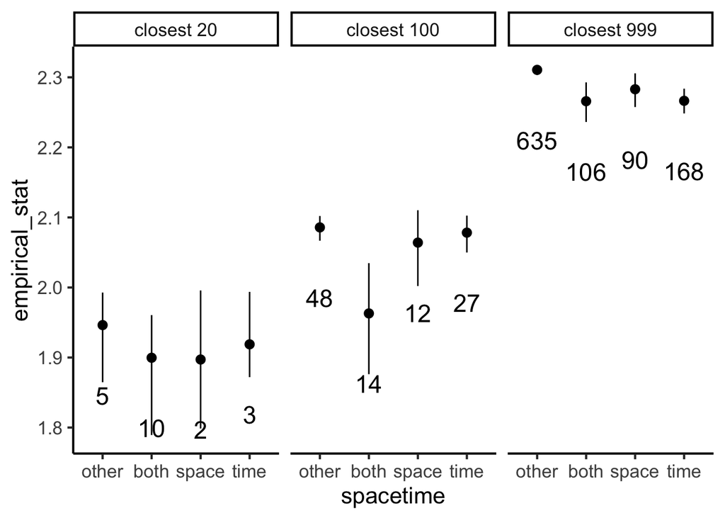

A plot of mean distances of space, time, both and other words from “short” within the closest 20, 100, and 999 neighbors.

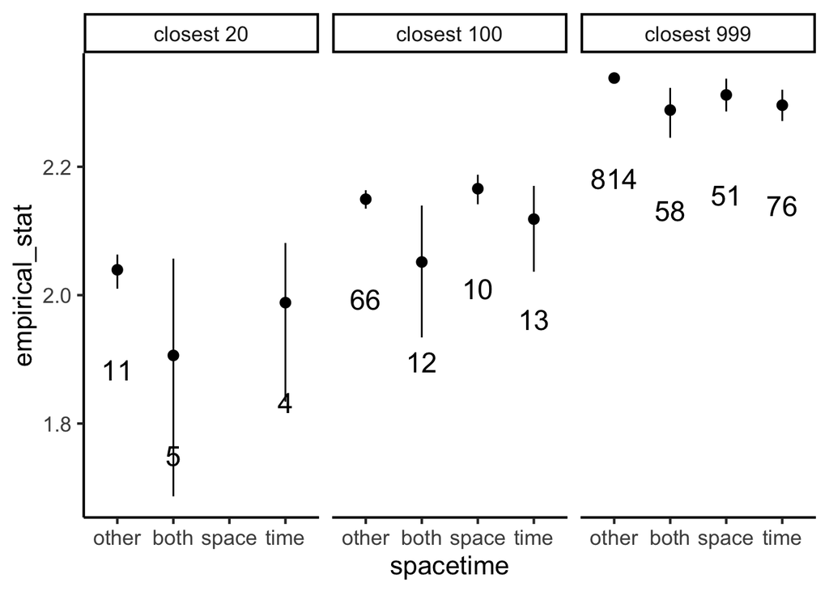

Linear model predicting distance from “long” by word type (space, time, etc.) in the closest 100 words, where we’re more likely to see differences. Space is the reference category. Space and time are not significantly different.

```
##
## Call:
## glm(formula = expdist ~ spacetime, family = gaussian, data = longmodeldata)
##
## Deviance Residuals:
##      Min        1Q    Median        3Q       Max
## -0.44707  -0.02927   0.01767   0.04510   0.18819
##
## Coefficients:
##                Estimate Std. Error t value Pr(>|t|)
## (Intercept)     2.06407    0.02546  81.074  < 2e-16 ***
## spacetimeboth  -0.10112    0.03469  -2.914  0.00442 **
## spacetimeother  0.02169    0.02846   0.762  0.44799
## spacetimetime   0.01419    0.03060   0.464  0.64389
## ---
## Signif. codes:  0 '***' 0.001 '**' 0.01 '*' 0.05 '.' 0.1 ' ' 1
##
## (Dispersion parameter for gaussian family taken to be 0.007777961)
##
##     Null deviance: 0.92562  on 100  degrees of freedom
## Residual deviance: 0.75446  on  97  degrees of freedom
## AIC: -197.96
##
## Number of Fisher Scoring iterations: 2
```

Linear model predicting distance from “short” by word type (space, time, etc.) in the closest 100 words, where we’re more likely to see differences. Space is the reference category. Space and time are not significantly different.

```
##
## Call:
## glm(formula = expdist ~ spacetime, family = gaussian, data = shortmodeldata)
##
## Deviance Residuals:
##      Min        1Q    Median        3Q       Max
## -0.53576  -0.02826   0.02327   0.04950   0.13638
##
## Coefficients:
##                Estimate Std. Error t value Pr(>|t|)
## (Intercept)     2.16587    0.02908  74.482   <2e-16 ***
## spacetimeother -0.01637    0.03120  -0.525   0.6011
## spacetimeboth  -0.11421    0.03937  -2.901   0.0046 **
## spacetimetime  -0.04740    0.03868  -1.226   0.2233
## ---
## Signif. codes:  0 '***' 0.001 '**' 0.01 '*' 0.05 '.' 0.1 ' ' 1
##
## (Dispersion parameter for gaussian family taken to be 0.008455896)
##
##     Null deviance: 0.93051  on 100  degrees of freedom
## Residual deviance: 0.82022  on  97  degrees of freedom
## AIC: -189.52
##
## Number of Fisher Scoring iterations: 2
```